# Case Study 02

## Group 4

### Leonardo Patricelli 101292853

## #

## #

## #

## #

## Loading the dataset and descriptive statistics

```python
import pandas as pd
import matplotlib.pylab as plt
from mlxtend.frequent_patterns import apriori
from mlxtend.frequent_patterns import association_rules
```

```python
df = pd.read_excel('CatalogCrossSell.xlsx')
df
```

|  | Customer Number | Clothing Division | Housewares Division | Health Products Division | Automotive Division | Personal Electronics Division | Computers Division | Garden Division | Novelty Gift Division | Jewelry Division |
| --- | --- | --- | --- | --- | --- | --- | --- | --- | --- | --- |
| 0 | 11569 | 0 | 1 | 1 | 1 | 1 | 0 | 0 | 1 | 0 |
| 1 | 13714 | 0 | 1 | 1 | 1 | 1 | 0 | 1 | 1 | 1 |
| 2 | 46391 | 0 | 1 | 1 | 1 | 1 | 0 | 1 | 1 | 1 |
| 3 | 67264 | 0 | 0 | 1 | 1 | 1 | 0 | 1 | 1 | 0 |
| 4 | 67363 | 0 | 0 | 1 | 0 | 1 | 0 | 1 | 1 | 0 |
| ... | ... | ... | ... | ... | ... | ... | ... | ... | ... | ... |
| 4993 | 337441034 | 0 | 0 | 1 | 0 | 0 | 0 | 0 | 0 | 0 |
| 4994 | 337498968 | 0 | 1 | 1 | 0 | 0 | 0 | 1 | 0 | 1 |
| 4995 | 337516678 | 0 | 0 | 1 | 0 | 1 | 0 | 0 | 0 | 1 |
| 4996 | 337528921 | 0 | 0 | 1 | 0 | 0 | 0 | 0 | 0 | 0 |
| 4997 | 337534044 | 0 | 0 | 1 | 0 | 0 | 0 | 0 | 0 | 0 |

4998 rows × 10 columns

We have 4998 rows and 4998 Customers. It means each row is a different transaction, and the same user does not appear 2 times

```python
df.nunique()
```

```
Customer Number                  4998
Clothing Division                   2
Housewares Division                 2
Health Products Division            1
Automotive Division                 2
Personal Electronics Division       2
Computers Division                  2
Garden Division                     2
Novelty Gift Division               2
Jewelry Division                    2
dtype: int64
```

Checking null values

```python
df.isnull().sum()
```

```
Customer Number                  0
Clothing Division                0
Housewares Division              0
Health Products Division         0
Automotive Division              0
Personal Electronics Division    0
Computers Division               0
Garden Division                  0
Novelty Gift Division            0
Jewelry Division                 0
dtype: int64
```

Value Counts per Column

```python
del df['Customer Number']
a = df.apply(pd.value_counts).fillna(0).astype(int)
a.head(2)
```

|  | Clothing Division | Housewares Division | Health Products Division | Automotive Division | Personal Electronics Division | Computers Division | Garden Division | Novelty Gift Division | Jewelry Division |
| --- | --- | --- | --- | --- | --- | --- | --- | --- | --- |
| 0 | 4833 | 3031 | 0 | 4324 | 2662 | 4764 | 3638 | 3861 | 3214 |
| 1 | 165 | 1967 | 4998 | 674 | 2336 | 234 | 1360 | 1137 | 1784 |

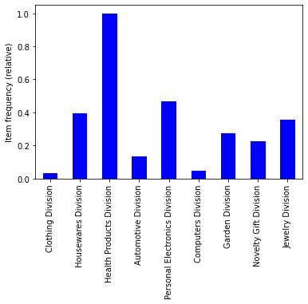

```python
# determine item frequencies
itemFrequency = df.sum(axis=0) / len(df)

# and plot as histogram
ax = itemFrequency.plot.bar(color='blue')
plt.ylabel('Item frequency (relative)')
plt.show()
```

We can see what are the most popular and less popular divisions in absolute terms

SInce Health Products Division it's in all the transactions, it's useless keeping taking it into consideration.

```python
del df['Health Products Division']
```

we are going to take all the transaction that appear at least 10% of the times (support = 0.1)

```python
# create frequent itemsets
itemsets = apriori(df, min_support =0.1, use_colnames=True)
itemsets
```

|  | support | itemsets |
| --- | --- | --- |
| 0 | 0.393557 | (Housewares Division) |
| 1 | 0.134854 | (Automotive Division) |
| 2 | 0.467387 | (Personal Electronics Division) |
| 3 | 0.272109 | (Garden Division) |
| 4 | 0.227491 | (Novelty Gift Division) |
| 5 | 0.356943 | (Jewelry Division) |
| 6 | 0.235494 | (Personal Electronics Division, Housewares Div... |
| 7 | 0.132853 | (Garden Division, Housewares Division) |
| 8 | 0.134854 | (Novelty Gift Division, Housewares Division) |
| 9 | 0.194878 | (Jewelry Division, Housewares Division) |
| 10 | 0.163265 | (Garden Division, Personal Electronics Division) |
| 11 | 0.169068 | (Novelty Gift Division, Personal Electronics D... |
| 12 | 0.197479 | (Jewelry Division, Personal Electronics Division) |
| 13 | 0.112245 | (Novelty Gift Division, Garden Division) |
| 14 | 0.127251 | (Garden Division, Jewelry Division) |
| 15 | 0.107243 | (Novelty Gift Division, Jewelry Division) |
| 16 | 0.107843 | (Novelty Gift Division, Personal Electronics D... |
| 17 | 0.132053 | (Jewelry Division, Personal Electronics Divisi... |

Let's have a look at all the meaningful rules

```python
# create frequent itemsets and rules
itemsets = apriori(df, min_support =0.1, use_colnames=True)
rules = association_rules(itemsets, metric='confidence', min_threshold=0)

print('Number of rules:', len(rules))

# Display rules with highest lift
rules.sort_values(by=['lift'], ascending=False).head(32)


rules.sort_values(by=['lift'], ascending=False).drop(columns=['antecedent support', 'consequent support', 'conviction']).head(32)
```

```
Number of rules: 32
```

|  | antecedents | consequents | support | confidence | lift | leverage |
| --- | --- | --- | --- | --- | --- | --- |
| 22 | (Personal Electronics Division, Housewares Div... | (Novelty Gift Division) | 0.107843 | 0.457944 | 2.013020 | 0.054270 |
| 23 | (Novelty Gift Division) | (Personal Electronics Division, Housewares Div... | 0.107843 | 0.474055 | 2.013020 | 0.054270 |
| 15 | (Garden Division) | (Novelty Gift Division) | 0.112245 | 0.412500 | 1.813259 | 0.050343 |
| 14 | (Novelty Gift Division) | (Garden Division) | 0.112245 | 0.493404 | 1.813259 | 0.050343 |
| 21 | (Novelty Gift Division, Housewares Division) | (Personal Electronics Division) | 0.107843 | 0.799703 | 1.711009 | 0.044814 |
| 24 | (Personal Electronics Division) | (Novelty Gift Division, Housewares Division) | 0.107843 | 0.230736 | 1.711009 | 0.044814 |
| 26 | (Jewelry Division, Personal Electronics Division) | (Housewares Division) | 0.132053 | 0.668693 | 1.699099 | 0.054333 |
| 31 | (Housewares Division) | (Jewelry Division, Personal Electronics Division) | 0.132053 | 0.335536 | 1.699099 | 0.054333 |
| 20 | (Novelty Gift Division, Personal Electronics D... | (Housewares Division) | 0.107843 | 0.637870 | 1.620780 | 0.041305 |
| 25 | (Housewares Division) | (Novelty Gift Division, Personal Electronics D... | 0.107843 | 0.274021 | 1.620780 | 0.041305 |
| 11 | (Personal Electronics Division) | (Novelty Gift Division) | 0.169068 | 0.361729 | 1.590082 | 0.062741 |
| 10 | (Novelty Gift Division) | (Personal Electronics Division) | 0.169068 | 0.743184 | 1.590082 | 0.062741 |
| 29 | (Jewelry Division) | (Personal Electronics Division, Housewares Div... | 0.132053 | 0.369955 | 1.570974 | 0.047995 |
| 28 | (Personal Electronics Division, Housewares Div... | (Jewelry Division) | 0.132053 | 0.560748 | 1.570974 | 0.047995 |
| 5 | (Housewares Division) | (Novelty Gift Division) | 0.134854 | 0.342654 | 1.506230 | 0.045323 |
| 4 | (Novelty Gift Division) | (Housewares Division) | 0.134854 | 0.592788 | 1.506230 | 0.045323 |
| 27 | (Jewelry Division, Housewares Division) | (Personal Electronics Division) | 0.132053 | 0.677618 | 1.449801 | 0.040969 |
| 30 | (Personal Electronics Division) | (Jewelry Division, Housewares Division) | 0.132053 | 0.282534 | 1.449801 | 0.040969 |
| 7 | (Housewares Division) | (Jewelry Division) | 0.194878 | 0.495170 | 1.387254 | 0.054400 |
| 6 | (Jewelry Division) | (Housewares Division) | 0.194878 | 0.545964 | 1.387254 | 0.054400 |
| 18 | (Novelty Gift Division) | (Jewelry Division) | 0.107243 | 0.471416 | 1.320705 | 0.026042 |
| 19 | (Jewelry Division) | (Novelty Gift Division) | 0.107243 | 0.300448 | 1.320705 | 0.026042 |
| 16 | (Garden Division) | (Jewelry Division) | 0.127251 | 0.467647 | 1.310146 | 0.030124 |
| 17 | (Jewelry Division) | (Garden Division) | 0.127251 | 0.356502 | 1.310146 | 0.030124 |
| 9 | (Personal Electronics Division) | (Garden Division) | 0.163265 | 0.349315 | 1.283733 | 0.036085 |
| 8 | (Garden Division) | (Personal Electronics Division) | 0.163265 | 0.600000 | 1.283733 | 0.036085 |
| 1 | (Housewares Division) | (Personal Electronics Division) | 0.235494 | 0.598373 | 1.280252 | 0.051551 |
| 0 | (Personal Electronics Division) | (Housewares Division) | 0.235494 | 0.503853 | 1.280252 | 0.051551 |
| 3 | (Housewares Division) | (Garden Division) | 0.132853 | 0.337570 | 1.240569 | 0.025763 |
| 2 | (Garden Division) | (Housewares Division) | 0.132853 | 0.488235 | 1.240569 | 0.025763 |
| 13 | (Personal Electronics Division) | (Jewelry Division) | 0.197479 | 0.422517 | 1.183711 | 0.030649 |
| 12 | (Jewelry Division) | (Personal Electronics Division) | 0.197479 | 0.553251 | 1.183711 | 0.030649 |

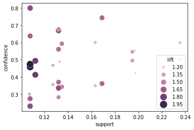

```python
import seaborn as sns

sns.scatterplot(data=rules, x="support", y="confidence", hue='lift', size='lift',
               sizes=(20, 200), )
```

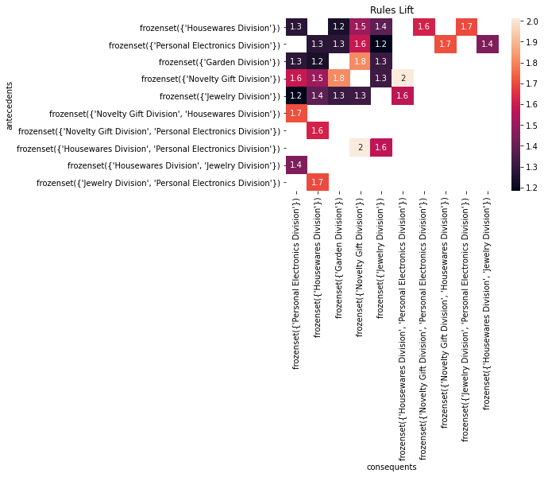

```python
import seaborn as sns

# Transform antecedent, consequent, and support columns into matrix
support_table = rules.pivot(index='antecedents', columns='consequents', values='lift')

# Generate heatmap


ax = plt.axes()
ax.set_title('Rules Lift')
sns.heatmap(support_table, annot=True)
plt.show()
```

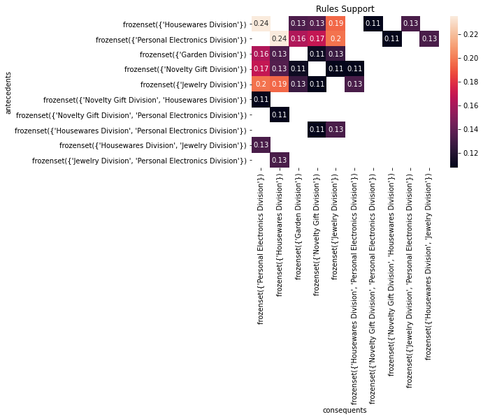

```python
# Transform antecedent, consequent, and support columns into matrix
support_table = rules.pivot(index='antecedents', columns='consequents', values='support')

# Generate heatmap

ax = plt.axes()
ax.set_title('Rules Support')
sns.heatmap(support_table, annot=True)
plt.show()
```

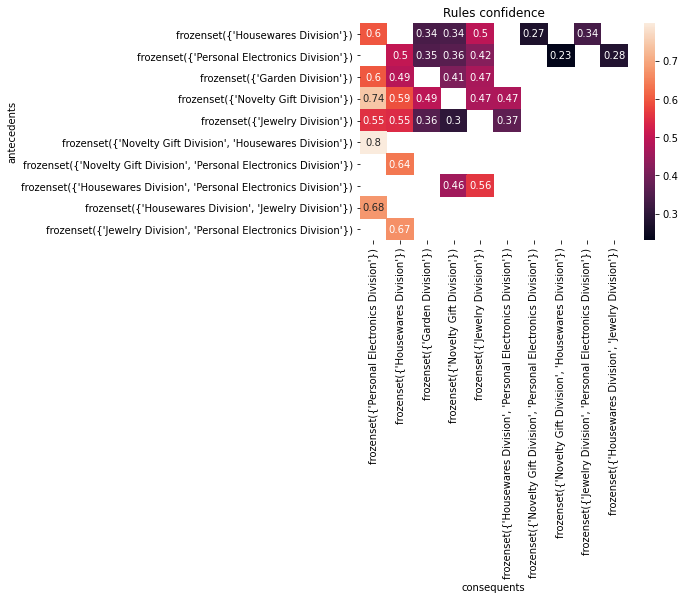

```python
# Transform antecedent, consequent, and support columns into matrix
support_table = rules.pivot(index='antecedents', columns='consequents', values='confidence')

# Generate heatmap

ax = plt.axes()
ax.set_title('Rules confidence')
sns.heatmap(support_table, annot=True)
plt.show()
```

```python
print('2 Antecedents and 1 consequent')
# Filter rules by number of antecedents (maximum 2) and consequents (maximum 1)
rules_21 = rules[[len(c) == 2 for c in rules.antecedents]]
rules_21 = rules_21[[len(c) == 1 for c in rules_21.consequents]]

print('Number of rules:', len(rules_21))

rules_21.sort_values(by=['lift'], ascending=False).head(10)
```

```
2 Antecedents and 1 consequent
Number of rules: 6
```

|  | antecedents | consequents | antecedent support | consequent support | support | confidence | lift | leverage | conviction |
| --- | --- | --- | --- | --- | --- | --- | --- | --- | --- |
| 22 | (Housewares Division, Personal Electronics Div... | (Novelty Gift Division) | 0.235494 | 0.227491 | 0.107843 | 0.457944 | 2.013020 | 0.054270 | 1.425146 |
| 20 | (Novelty Gift Division, Housewares Division) | (Personal Electronics Division) | 0.134854 | 0.467387 | 0.107843 | 0.799703 | 1.711009 | 0.044814 | 2.659120 |
| 27 | (Jewelry Division, Personal Electronics Division) | (Housewares Division) | 0.197479 | 0.393557 | 0.132053 | 0.668693 | 1.699099 | 0.054333 | 1.830455 |
| 21 | (Novelty Gift Division, Personal Electronics D... | (Housewares Division) | 0.169068 | 0.393557 | 0.107843 | 0.637870 | 1.620780 | 0.041305 | 1.674654 |
| 28 | (Housewares Division, Personal Electronics Div... | (Jewelry Division) | 0.235494 | 0.356943 | 0.132053 | 0.560748 | 1.570974 | 0.047995 | 1.463981 |
| 26 | (Housewares Division, Jewelry Division) | (Personal Electronics Division) | 0.194878 | 0.467387 | 0.132053 | 0.677618 | 1.449801 | 0.040969 | 1.652118 |

```python
print('1 Antecedents and 1 consequent')
# Filter rules by number of antecedents (maximum 2) and consequents (maximum 1)
rules_11 = rules[[len(c) == 1 for c in rules.antecedents]]
rules_11 = rules_11[[len(c) == 1 for c in rules_11.consequents]]

print('Number of rules:', len(rules_11))

rules_11.sort_values(by=['lift'], ascending=False).head(10)
```

```
1 Antecedents and 1 consequent
Number of rules: 20
```

|  | antecedents | consequents | antecedent support | consequent support | support | confidence | lift | leverage | conviction |
| --- | --- | --- | --- | --- | --- | --- | --- | --- | --- |
| 15 | (Novelty Gift Division) | (Garden Division) | 0.227491 | 0.272109 | 0.112245 | 0.493404 | 1.813259 | 0.050343 | 1.436827 |
| 14 | (Garden Division) | (Novelty Gift Division) | 0.272109 | 0.227491 | 0.112245 | 0.412500 | 1.813259 | 0.050343 | 1.314909 |
| 11 | (Personal Electronics Division) | (Novelty Gift Division) | 0.467387 | 0.227491 | 0.169068 | 0.361729 | 1.590082 | 0.062741 | 1.210316 |
| 10 | (Novelty Gift Division) | (Personal Electronics Division) | 0.227491 | 0.467387 | 0.169068 | 0.743184 | 1.590082 | 0.062741 | 2.073908 |
| 4 | (Novelty Gift Division) | (Housewares Division) | 0.227491 | 0.393557 | 0.134854 | 0.592788 | 1.506230 | 0.045323 | 1.489255 |
| 5 | (Housewares Division) | (Novelty Gift Division) | 0.393557 | 0.227491 | 0.134854 | 0.342654 | 1.506230 | 0.045323 | 1.175194 |
| 7 | (Housewares Division) | (Jewelry Division) | 0.393557 | 0.356943 | 0.194878 | 0.495170 | 1.387254 | 0.054400 | 1.273810 |
| 6 | (Jewelry Division) | (Housewares Division) | 0.356943 | 0.393557 | 0.194878 | 0.545964 | 1.387254 | 0.054400 | 1.335671 |
| 18 | (Novelty Gift Division) | (Jewelry Division) | 0.227491 | 0.356943 | 0.107243 | 0.471416 | 1.320705 | 0.026042 | 1.216566 |
| 19 | (Jewelry Division) | (Novelty Gift Division) | 0.356943 | 0.227491 | 0.107243 | 0.300448 | 1.320705 | 0.026042 | 1.104292 |

```python
print('1 Antecedents and 2 consequent')
# Filter rules by number of antecedents (maximum 2) and consequents (maximum 1)
rules_12 = rules[[len(c) == 1 for c in rules.antecedents]]
rules_12 = rules_12[[len(c) == 2 for c in rules_12.consequents]]

print('Number of rules:', len(rules_12))


rules_12.sort_values(by=['lift'], ascending=False).head(10)
```

```
1 Antecedents and 2 consequent
Number of rules: 6
```

|  | antecedents | consequents | antecedent support | consequent support | support | confidence | lift | leverage | conviction |
| --- | --- | --- | --- | --- | --- | --- | --- | --- | --- |
| 23 | (Novelty Gift Division) | (Housewares Division, Personal Electronics Div... | 0.227491 | 0.235494 | 0.107843 | 0.474055 | 2.013020 | 0.054270 | 1.453584 |
| 25 | (Personal Electronics Division) | (Novelty Gift Division, Housewares Division) | 0.467387 | 0.134854 | 0.107843 | 0.230736 | 1.711009 | 0.044814 | 1.124642 |
| 30 | (Housewares Division) | (Jewelry Division, Personal Electronics Division) | 0.393557 | 0.197479 | 0.132053 | 0.335536 | 1.699099 | 0.054333 | 1.207773 |
| 24 | (Housewares Division) | (Novelty Gift Division, Personal Electronics D... | 0.393557 | 0.169068 | 0.107843 | 0.274021 | 1.620780 | 0.041305 | 1.144569 |
| 29 | (Jewelry Division) | (Housewares Division, Personal Electronics Div... | 0.356943 | 0.235494 | 0.132053 | 0.369955 | 1.570974 | 0.047995 | 1.213415 |
| 31 | (Personal Electronics Division) | (Housewares Division, Jewelry Division) | 0.467387 | 0.194878 | 0.132053 | 0.282534 | 1.449801 | 0.040969 | 1.122175 |

```python
print('2 Antecedents and 2 consequent')
# Filter rules by number of antecedents (maximum 2) and consequents (maximum 1)
rules_22 = rules[[len(c) == 2 for c in rules.antecedents]]
rules_22 = rules_22[[len(c) == 2 for c in rules_22.consequents]]

rules_22.sort_values(by=['lift'], ascending=False).head(10)
```

```
2 Antecedents and 2 consequent
```

|  | antecedents | consequents | antecedent support | consequent support | support | confidence | lift | leverage | conviction |
| --- | --- | --- | --- | --- | --- | --- | --- | --- | --- |

### Strongest rules by Confidence

```python
# create frequent itemsets and rules
itemsets = apriori(df, min_support =0.1, use_colnames=True)
rules = association_rules(itemsets, metric='confidence', min_threshold=0.6)

print('Number of rules:', len(rules))

# Display rules with highest lift
rules.sort_values(by=['lift'], ascending=False).head(32)


rules.sort_values(by=['lift'], ascending=False).drop(columns=['antecedent support', 'consequent support', 'conviction']).head(32)
```

```
Number of rules: 5
```

|  | antecedents | consequents | support | confidence | lift | leverage |
| --- | --- | --- | --- | --- | --- | --- |
| 1 | (Novelty Gift Division, Housewares Division) | (Personal Electronics Division) | 0.107843 | 0.799703 | 1.711009 | 0.044814 |
| 4 | (Jewelry Division, Personal Electronics Division) | (Housewares Division) | 0.132053 | 0.668693 | 1.699099 | 0.054333 |
| 2 | (Novelty Gift Division, Personal Electronics D... | (Housewares Division) | 0.107843 | 0.637870 | 1.620780 | 0.041305 |
| 0 | (Novelty Gift Division) | (Personal Electronics Division) | 0.169068 | 0.743184 | 1.590082 | 0.062741 |
| 3 | (Housewares Division, Jewelry Division) | (Personal Electronics Division) | 0.132053 | 0.677618 | 1.449801 | 0.040969 |

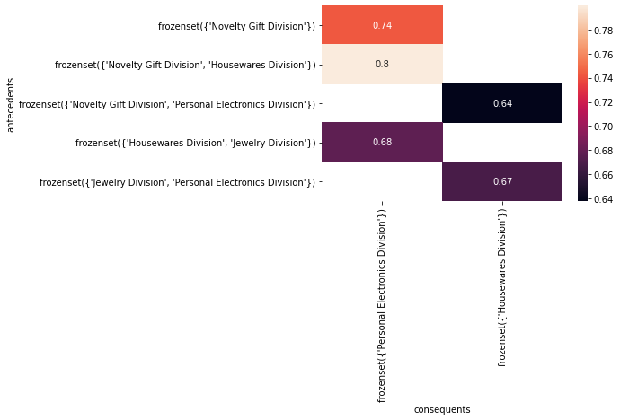

```python
# Transform antecedent, consequent, and support columns into matrix
support_table = rules.pivot(index='antecedents', columns='consequents', values='confidence')

# Generate heatmap
sns.heatmap(support_table, annot=True)
```

These rules have the highest confidence among all the transactions.

We can start to think that we can suggest Houseware or Personal Electronics coupon to the people who followed the rules (the Antecedents) and didn't buy the relative consequent

#### Strongest rules by Lift

```python
# create frequent itemsets and rules
itemsets = apriori(df, min_support =0.1, use_colnames=True)
rules = association_rules(itemsets, metric='confidence', min_threshold=0)

#print('Number of rules:', len(rules))

rules.sort_values(by=['lift'], ascending=False).drop(columns=['antecedent support', 'consequent support', 'conviction']).head(6)
```

|  | antecedents | consequents | support | confidence | lift | leverage |
| --- | --- | --- | --- | --- | --- | --- |
| 22 | (Housewares Division, Personal Electronics Div... | (Novelty Gift Division) | 0.107843 | 0.457944 | 2.013020 | 0.054270 |
| 23 | (Novelty Gift Division) | (Housewares Division, Personal Electronics Div... | 0.107843 | 0.474055 | 2.013020 | 0.054270 |
| 15 | (Novelty Gift Division) | (Garden Division) | 0.112245 | 0.493404 | 1.813259 | 0.050343 |
| 14 | (Garden Division) | (Novelty Gift Division) | 0.112245 | 0.412500 | 1.813259 | 0.050343 |
| 20 | (Novelty Gift Division, Housewares Division) | (Personal Electronics Division) | 0.107843 | 0.799703 | 1.711009 | 0.044814 |
| 25 | (Personal Electronics Division) | (Novelty Gift Division, Housewares Division) | 0.107843 | 0.230736 | 1.711009 | 0.044814 |

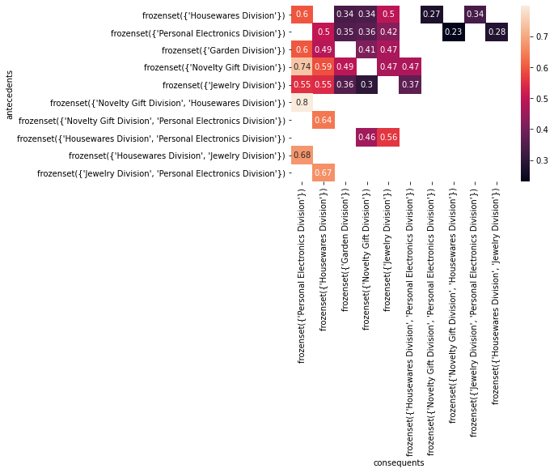

```python
# Transform antecedent, consequent, and support columns into matrix
support_table = rules.pivot(index='antecedents', columns='consequents', values='confidence')

# Generate heatmap
sns.heatmap(support_table, annot=True)
```

A Lift of 1 means there is no association between products A and B. Lift of greater than 1 means products A and B are more likely to be bought together. Finally, Lift of less than 1 refers to the case where two products are unlikely to be bought together.

Here we bring the top 6 rules by lift, using as threshold a lift of 1.7

It seems that Housewares Division, Novelty Gift Division and Personal Electronics Division are sticlty related. We could reccomend an item of those 3 to people who only bouth 2 of them.

Same for Garden Division and Novelty Gift Division.

### Most frequent rules

Let's analyze rules with a support over 0.17 (transaction that appear over 17% of the times)

```python
# create frequent itemsets and rules
itemsets = apriori(df, min_support =0.1, use_colnames=True)
rules = association_rules(itemsets, metric='support', min_threshold=0.17)

#print('Number of rules:', len(rules))

rules.sort_values(by=['support'], ascending=False).drop(columns=['antecedent support', 'consequent support', 'conviction']).head(10)
```

|  | antecedents | consequents | support | confidence | lift | leverage |
| --- | --- | --- | --- | --- | --- | --- |
| 0 | (Housewares Division) | (Personal Electronics Division) | 0.235494 | 0.598373 | 1.280252 | 0.051551 |
| 1 | (Personal Electronics Division) | (Housewares Division) | 0.235494 | 0.503853 | 1.280252 | 0.051551 |
| 4 | (Jewelry Division) | (Personal Electronics Division) | 0.197479 | 0.553251 | 1.183711 | 0.030649 |
| 5 | (Personal Electronics Division) | (Jewelry Division) | 0.197479 | 0.422517 | 1.183711 | 0.030649 |
| 2 | (Jewelry Division) | (Housewares Division) | 0.194878 | 0.545964 | 1.387254 | 0.054400 |
| 3 | (Housewares Division) | (Jewelry Division) | 0.194878 | 0.495170 | 1.387254 | 0.054400 |

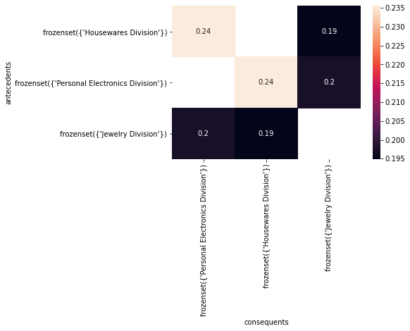

```python
# Transform antecedent, consequent, and support columns into matrix
support_table = rules.pivot(index='antecedents', columns='consequents', values='support')

# Generate heatmap
sns.heatmap(support_table, annot=True)
```

Those rules are the most frequent in the data. The lift is not really high.

It seems that Housewares Division, Personal Electronics Division, Jewelry Division are correlated.

### Customer segmentation via Gaussian Mixture Model

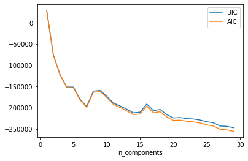

```python
from sklearn.mixture import GaussianMixture
import numpy as np

n_components = np.arange(1, 30)
models = [GaussianMixture(n, covariance_type='full', random_state=0).fit(df)
          for n in n_components]

plt.plot(n_components, [m.bic(df) for m in models], label='BIC')
plt.plot(n_components, [m.aic(df) for m in models], label='AIC')
plt.legend(loc='best')
plt.xlabel('n_components');
```

#### It seems the best value lies between 4 and 7

```python
gmm = GaussianMixture(n_components=7).fit(df)
GMM7_df = gmm.predict(df)

gmm = GaussianMixture(n_components=4).fit(df)
GMM4_df = gmm.predict(df)

gmm = GaussianMixture(n_components=5).fit(df)
GMM5_df = gmm.predict(df)

gmm = GaussianMixture(n_components=6).fit(df)
GMM6_df = gmm.predict(df)

gmm = GaussianMixture(n_components=3).fit(df)
GMM3_df = gmm.predict(df)
```

```python
df['GMM7_df'] = GMM7_df
df['GMM6_df'] = GMM6_df
df['GMM5_df'] = GMM5_df
df['GMM4_df'] = GMM4_df
df['GMM3_df'] = GMM3_df
```

```python
gmm7 = df.groupby('GMM7_df').mean()
gmm6 = df.groupby('GMM6_df').mean()
gmm5 = df.groupby('GMM5_df').mean()
gmm4 = df.groupby('GMM4_df').mean()
gmm3 = df.groupby('GMM3_df').mean()
```

## Meaning of the table

The numbers in the table are percentage of time an item of that category is bought.

1 = each time there is a transaction in this group, there is always at least one item from this category.

0 = This category never appear in the transactions of the segment created.

0.72 = in 72% of the transactions, there is at least one item of this category

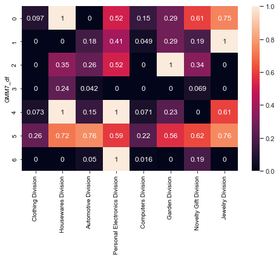

```python
import seaborn as sns
from matplotlib import pyplot


a4_dims = (8, 5)

fig, ax = pyplot.subplots(figsize=a4_dims)

sns.set_theme()
ax = sns.heatmap(gmm7.iloc[:,:-4], annot=True,)
```

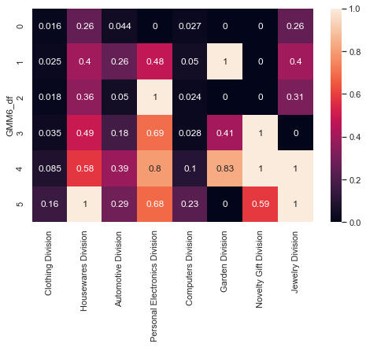

```python
sns.set_theme()

a4_dims = (8, 5)
fig, ax = pyplot.subplots(figsize=a4_dims)

ax = sns.heatmap(gmm6.iloc[:,:-4], annot=True,)
```

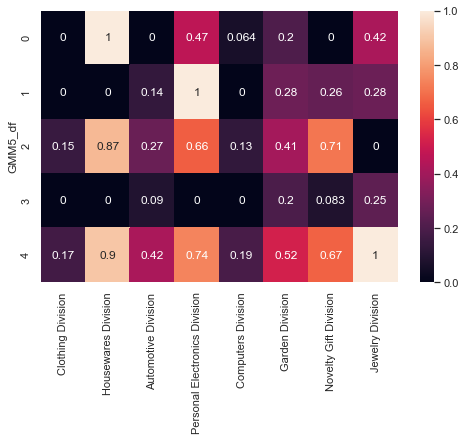

```python
sns.set_theme()

a4_dims = (8, 5)
fig, ax = pyplot.subplots(figsize=a4_dims)

ax = sns.heatmap(gmm5.iloc[:,:-4], annot=True,)
```

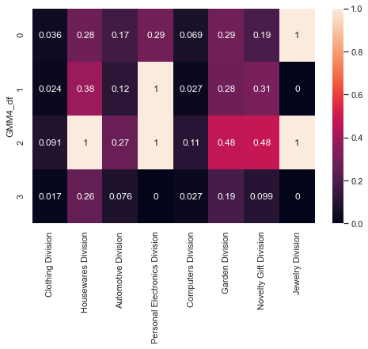

```python
sns.set_theme()

a4_dims = (8, 5)
fig, ax = pyplot.subplots(figsize=a4_dims)

ax = sns.heatmap(gmm4.iloc[:,:-4], annot=True,)
```

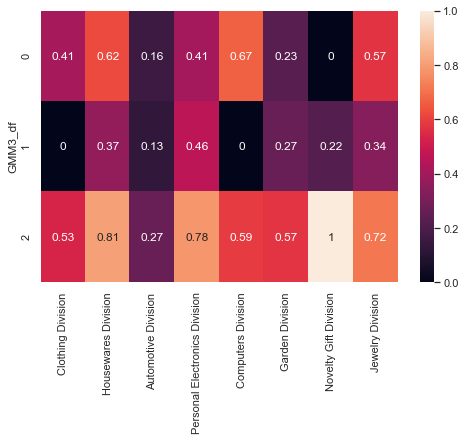

```python
sns.set_theme()

a4_dims = (8, 5)
fig, ax = pyplot.subplots(figsize=a4_dims)

ax = sns.heatmap(gmm3.iloc[:,:-4], annot=True,)
```

#### Best Customer segmentation according to Gaussian Mixture Models

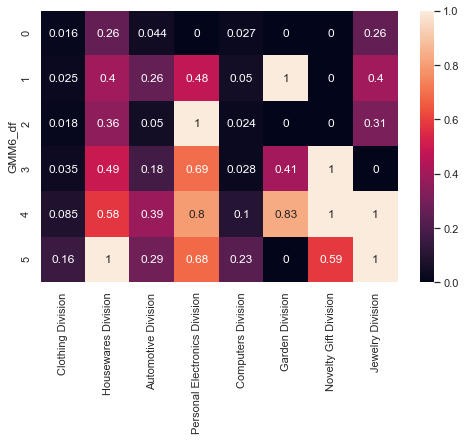

```python
sns.set_theme()

a4_dims = (8, 5)
fig, ax = pyplot.subplots(figsize=a4_dims)

ax = sns.heatmap(gmm6.iloc[:,:-4], annot=True,)
```

```python
df.GMM6_df.value_counts()
```

```
0    1897
2    1054
1     799
3     601
4     378
5     269
Name: GMM6_df, dtype: int64
```

Here the groups

- 0 = Occasional buyers
- 1 = People interested in gardening
- 2 = People interested in personal electronics
- 3 = People interested in Novelty gift and personal electronics
- 4 = People interested in novelty gift and Jewelry
- 5 = People interested in houseware and jewelry mostly, but also personal electronics

### Customer segmentation via K-means

```python
from sklearn.metrics import silhouette_score
from sklearn.cluster import KMeans


silhouette_coefficients = []
K = range(2,30)
for k in K:
    km = KMeans(n_clusters=k)
    km = km.fit(df)
    score = silhouette_score(df, km.labels_)
    silhouette_coefficients.append(score)

# silhouette_coefficients
```

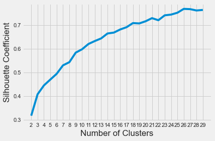

```python
plt.style.use("fivethirtyeight")
plt.plot(range(2, 30), silhouette_coefficients)
plt.xticks(range(2, 30))
plt.xlabel("Number of Clusters")
plt.ylabel("Silhouette Coefficient")
plt.show()
```

```python
kmeans = KMeans(
    init="k-means++",
    n_clusters=5,
    n_init=10,
    max_iter=600,
    random_state=42
)

kmeans.fit(df)
km5 = kmeans.labels_

# movie_PCA['KM3'] = km3
# movie_PCA['KM4'] = km4
# movie_PCA
```

```python
kmeans = KMeans(
    init="k-means++",
    n_clusters=6,
    n_init=10,
    max_iter=600,
    random_state=42
)

kmeans.fit(df)
km6 = kmeans.labels_

# movie_PCA['KM3'] = km3
# movie_PCA['KM4'] = km4
# movie_PCA
```

```python
kmeans = KMeans(
    init="k-means++",
    n_clusters=7,
    n_init=10,
    max_iter=600,
    random_state=42
)

kmeans.fit(df)
km7 = kmeans.labels_

# movie_PCA['KM3'] = km3
# movie_PCA['KM4'] = km4
# movie_PCA
```

```python
kmeans = KMeans(
    init="k-means++",
    n_clusters=8,
    n_init=10,
    max_iter=600,
    random_state=42
)

kmeans.fit(df)
km8 = kmeans.labels_
```

```python
df['km5'] = km5
df['km6'] = km6
df['km7'] = km7
df['km8'] = km8
```

```python
km5_df = df.groupby('km5').mean()
km6_df = df.groupby('km6').mean()
km7_df = df.groupby('km7').mean()
km8_df = df.groupby('km8').mean()
```

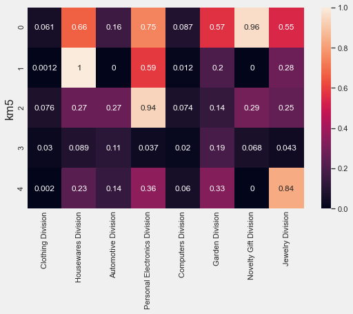

```python
import seaborn as sns
from matplotlib import pyplot


a4_dims = (8, 5)

fig, ax = pyplot.subplots(figsize=a4_dims)

sns.set_theme()
ax = sns.heatmap(km5_df.iloc[:,:-8], annot=True,)
```

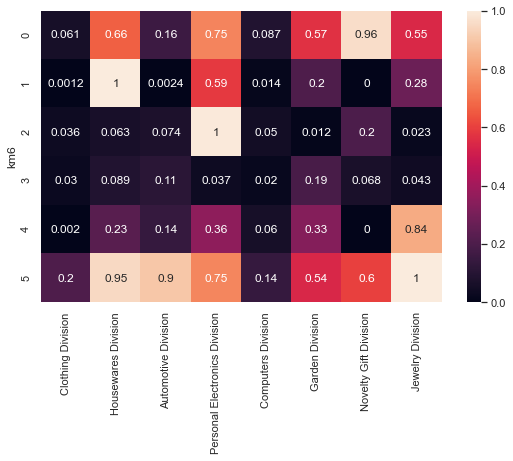

```python
import seaborn as sns
from matplotlib import pyplot


a4_dims = (8, 5)

fig, ax = pyplot.subplots(figsize=a4_dims)

sns.set_theme()
ax = sns.heatmap(km6_df.iloc[:,:-8], annot=True,)
```

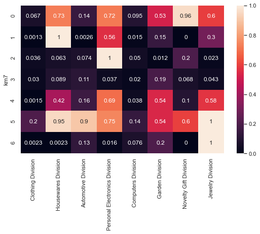

```python
import seaborn as sns
from matplotlib import pyplot


a4_dims = (8, 5)

fig, ax = pyplot.subplots(figsize=a4_dims)

sns.set_theme()
ax = sns.heatmap(km7_df.iloc[:,:-8], annot=True,)
```

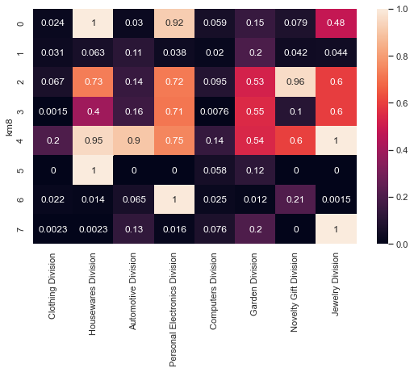

```python
import seaborn as sns
from matplotlib import pyplot


a4_dims = (8, 5)

fig, ax = pyplot.subplots(figsize=a4_dims)

sns.set_theme()
ax = sns.heatmap(km8_df.iloc[:,:-8], annot=True,)
```

## Best customer segmentation according to K-means clutering

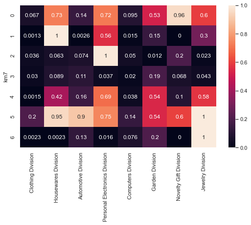

```python
import seaborn as sns
from matplotlib import pyplot


a4_dims = (8, 5)

fig, ax = pyplot.subplots(figsize=a4_dims)

sns.set_theme()
ax = sns.heatmap(km7_df.iloc[:,:-8], annot=True,)
```

Here the groups :

0 = People who mostly buy Novelty gfts but also pesonale electronics and houseware 1 = People who buy mostly persoal houseware; 2 = People who buy personal electronics; 3 = Occasional customers; 4 = People who buy mostly personal eletronics, but also houseware, garden and jewelry 5 = People who buy lots of stuff; 6 = People who buy jewelries.

I think The other one works better (created via GMM)